# Лабораторная работа №8

Администрирование локальных сетей

Ибрахим Мохсейн Алькамаль

1032225432@rudn.ru

Российский университет дружбы народов

2026-04-04

# Информация

## Докладчик

- Ибрахим Мохсейн Алькамаль
- Российский университет дружбы народов
- [GitHub](https://github.com/Ebrahimalkamal2027)

# Цель работы

## Цель работы

- Настройка DHCP
- Изучение динамической адресации
- Работа в локальной сети

# Выполнение лабораторной работы

## Подключение DNS-сервера

- Добавлен DNS-сервер
- Подключён к msk-donskaya-sw-3
- Использован порт Fa0/2
- Настроен VLAN 3

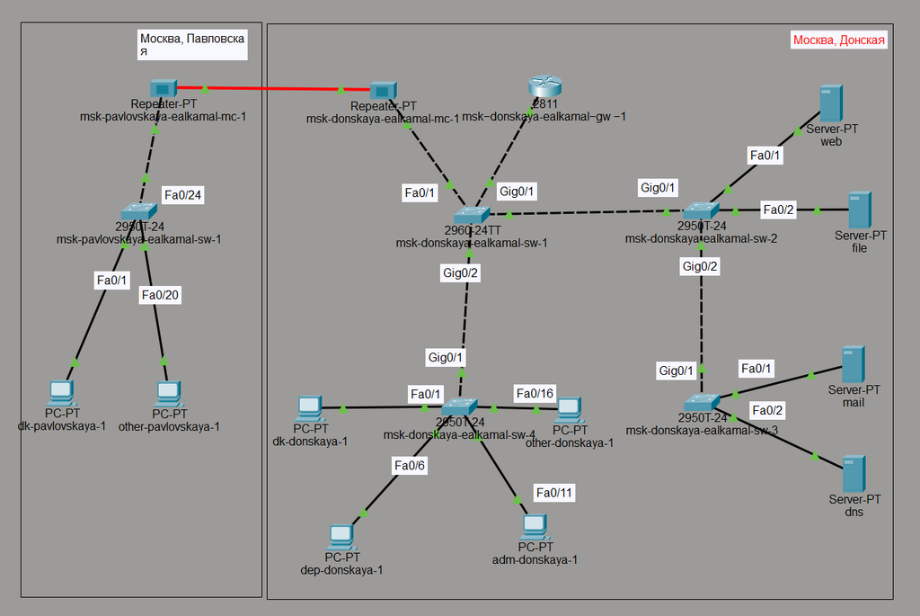

Рисунок 1: Топология сети с подключением DNS-сервера к коммутатору msk-donskaya-sw-3

## Настройка IP DNS-сервера

- IP: 10.128.0.5
- Маска: 255.255.255.0
- Шлюз: 10.128.0.1

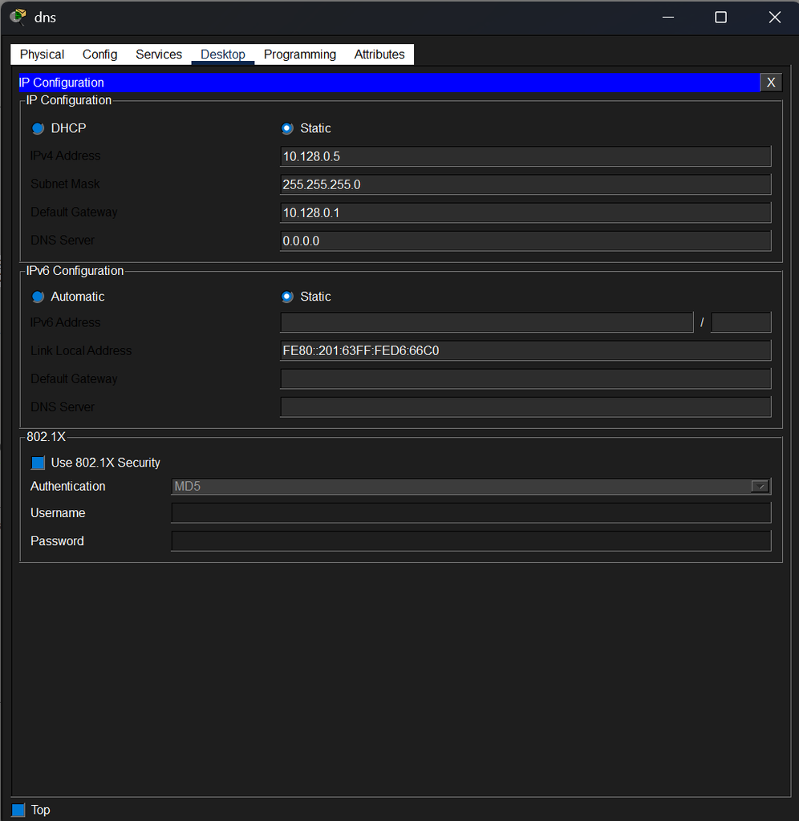

Рисунок 2: Конфигурация IP-параметров DNS-сервера

## Настройка порта коммутатора

- `interface fa0/2`
  - переход к настройке интерфейса
- `switchport mode access`
  - перевод порта в режим access
- `switchport access vlan 3`
  - назначение VLAN 3
- `no shutdown`
  - активация порта

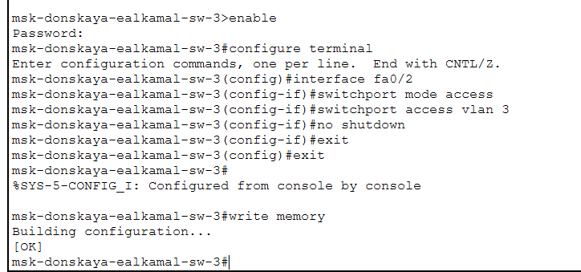

## Активация DNS-сервиса

- Включён DNS (On)
- Тип записи A Record для доменных имён:
  - A Record: Используется для сопоставления доменного имени с IPv4-адресом. Это позволяет пользователям обращаться к ресурсам по удобным именам, а не по числовым IP-адресам. Например:
- www.donskaya.rudn.ru → 10.128.0.2
- mail.donskaya.rudn.ru → 10.128.0.4
- file.donskaya.rudn.ru → 10.128.0.3
- dns.donskaya.rudn.ru → 10.128.0.5

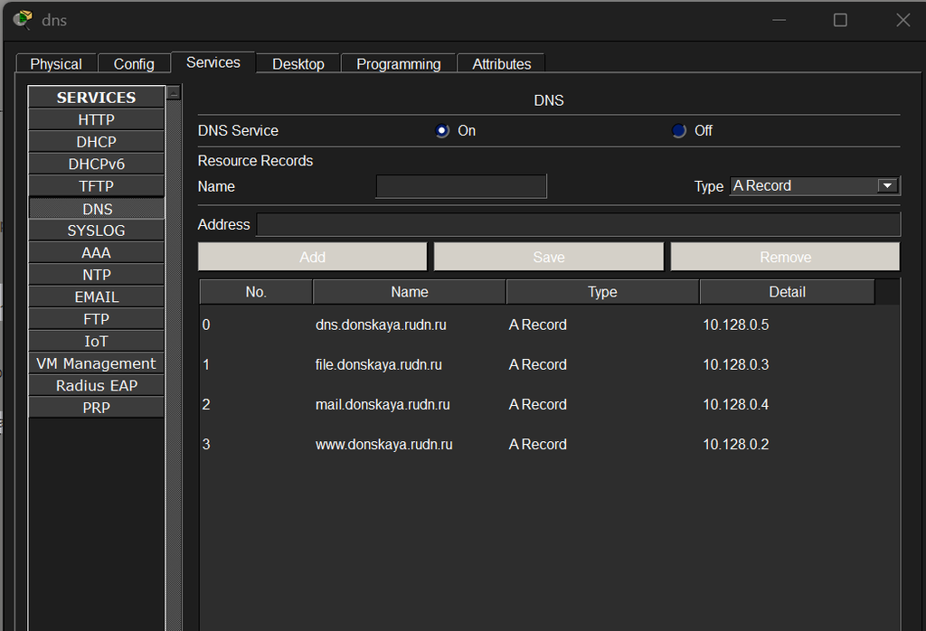

Рисунок 3: Настройка DNS-сервиса и добавление ресурсных записей типа A

## Настройка DHCP на маршрутизаторе

- Указан DNS: `ip name-server 10.128.0.5`
- Включён DHCP: `service dhcp`

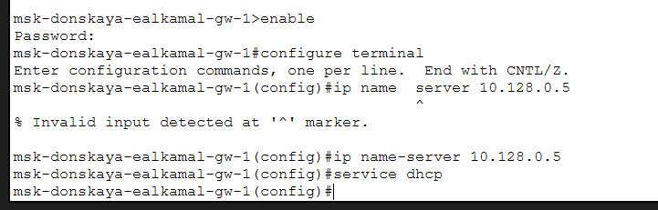

Рисунок 4: Настройка DNS-сервера и активация службы DHCP на маршрутизаторе

## DHCP пул dk

- Сеть 10.128.3.0
- `ip dhcp pool dk`:
  - создание пула: Используется для создания DHCP-пула с именем “dk”.
- `network 10.128.3.0 255.255.255.0`
  - задание сети для пула DHCP. Указывает, что пул будет выдавать адреса из сети
- `default-router 10.128.3.1`
  - указание шлюза
- `dns-server 10.128.0.5`
  - указание DNS

## DHCP пул dk

- `ip dhcp excluded-address 10.128.3.1 10.128.3.29`
  - исключение адресов:
- `ip dhcp excluded-address 10.128.3.200 10.128.3.254`
  - исключение адресов:

Указывает, что адреса от 10.128.3.1 до 10.128.3.29 И от 10.128.3.200 до 10.128.3.254 не будут выданы клиентам DHCP. Эти адреса могут быть зарезервированы для статической настройки устройств, таких как серверы, принтеры или другие важные устройства в сети.

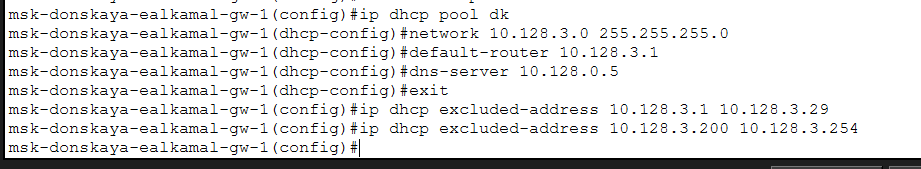

Рисунок 5: Конфигурация DHCP-пула для сети dk

## DHCP пул departments

- `ip dhcp pool departments`:
  - создание пула: Используется для создания DHCP-пула с именем “departments”.
- `network 10.128.4.0 255.255.255.0`
  - задание сети для пула DHCP. Указывает, что пул будет выдавать адреса из сети
- `default-router 10.128.4.1`
  - указание шлюза
- `dns-server 10.128.0.5`
  - указание DNS

## DHCP пул departments

- `ip dhcp excluded-address 10.128.4.1 10.128.4.29`
  - исключение адресов:
- `ip dhcp excluded-address 10.128.4.200 10.128.4.254`
  - исключение адресов:

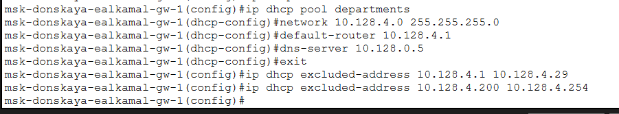

Рисунок 6: Конфигурация DHCP-пула для сети departments

## DHCP пул adm

- Сеть 10.128.5.0
- Шлюз 10.128.5.1
- исключение адресов: 10.128.5.1 10.128.5.29
- исключение адресов: 10.128.5.200 10.128.5.254

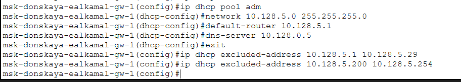

Рисунок 7: Конфигурация DHCP-пула для сети adm

## DHCP пул other

- Сеть 10.128.6.0
- Шлюз 10.128.6.1
- исключение адресов: 10.128.6.1 10.128.6.29
- исключение адресов: 10.128.6.200 10.128.6.254

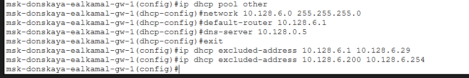

Рисунок 8: Конфигурация DHCP-пула для сети other

## Проверка DHCP pool

- Использована команда: `show ip dhcp pool` которая показала наличие всех настроенных пулов адресов, их параметры и доступное количество IP-адресов.

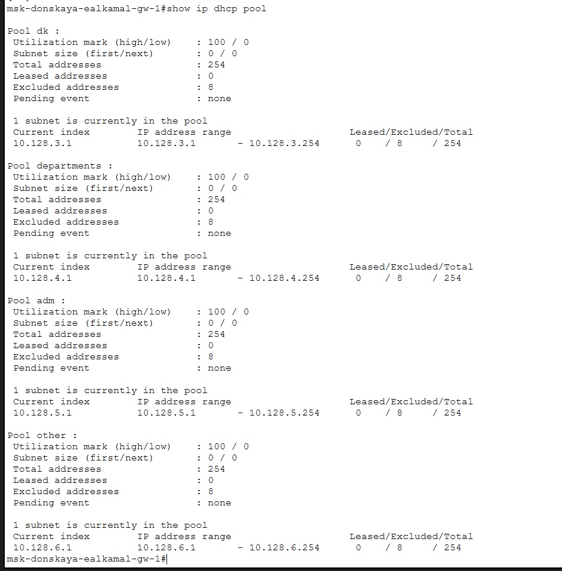

Рисунок 9: Результат проверки DHCP-пулов на маршрутизаторе

## Проверка DHCP binding

- Использована команда: `show ip dhcp binding`
- Клиенты отсутствуют

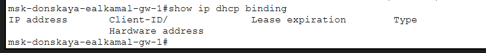

Рисунок 10: Проверка таблицы выданных DHCP-адресов

## Включение DHCP на ПК

- Выбран режим DHCP
- Получены IP автоматически

[figure not shown]

Рисунок 11: Получение IP-адреса по DHCP на устройстве dk-donskaya-1

## DHCP в разных VLAN

- DHCP работает корректно

[figure not shown]

Рисунок 12: Получение IP-адреса по DHCP на устройстве dep-donskaya-1

## DHCP на adm

- Адрес получен

[figure not shown]

Рисунок 13: Получение IP-адреса по DHCP на устройстве adm-donskaya-1

## DHCP на other

- Адрес получен

[figure not shown]

Рисунок 14: Получение IP-адреса по DHCP на устройстве other-donskaya-1

## Проверка выданных адресов

- Использована команда: `show ip dhcp binding`
- Отображены клиенты которая получили IP-адреса от DHCP-сервера

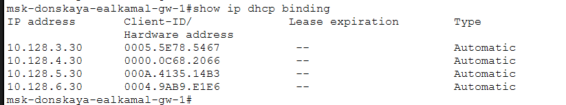

Рисунок 15: Таблица привязок DHCP на маршрутизаторе

## Проверка DNS

- Проверка www.donskaya.rudn.ru
- Имя преобразовано в IP
- Первый пакет потерян

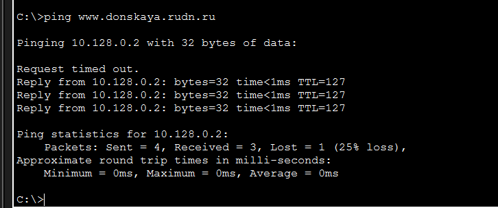

Рисунок 16: Проверка разрешения DNS-имени и доступности web-сервера по доменному имени

## Проверка между VLAN (dk)

- Доступ к другим сетям
- ICMP успешен

[figure not shown]

Рисунок 17: Проверка доступности узлов из подсети dk в других подсетях

## Проверка между VLAN (departments)

- Связь стабильна

[figure not shown]

Рисунок 18: Проверка доступности узлов из подсети departments в других подсетях

## Проверка между VLAN (adm)

- Минимальная задержка
- Сеть стабильна

[figure not shown]

Рисунок 19: Проверка межсетевой доступности с устройства adm-donskaya-1

## DHCP Simulation

- Discover: Клиент отправляет широковещательное сообщение DHCP Discover, чтобы найти доступные DHCP-серверы в сети.
- Offer : DHCP-сервер отвечает на Discover сообщением DHCP Offer, предлагая клиенту IP-адрес и другие параметры конфигурации.
- Request: Клиент выбирает один из предложенных серверов и отправляет ему DHCP Request, запрашивая назначенный IP-адрес.
- ACK: DHCP-сервер подтверждает запрос клиента сообщением DHCP ACK, окончательно назначая IP-адрес и предоставляя клиенту всю необходимую информацию для настройки сети.

## DHCP Simulation

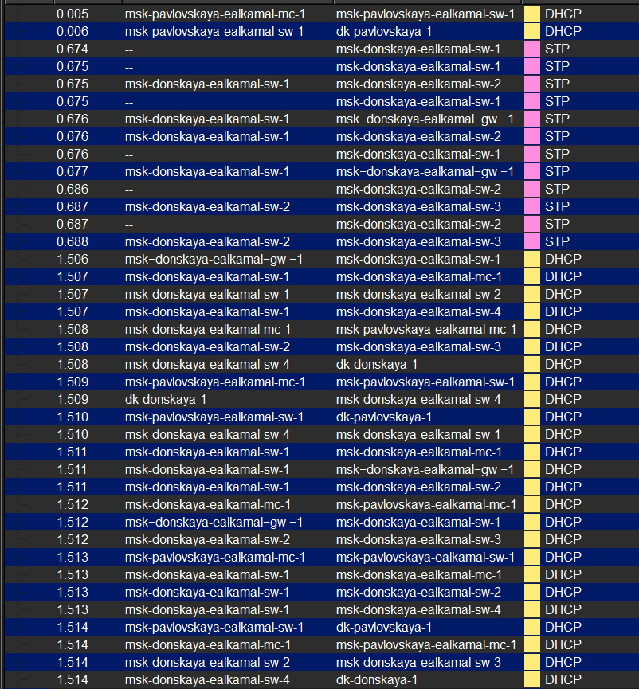

Рисунок 20: Процесс обмена DHCP-сообщениями в режиме симуляции Packet Tracer

# Выводы

## Выводы

- Настроен DHCP и DNS
- Автоматическая адресация работает
- Проверена связность
- DNS функционирует
- Изучен процесс DHCP
- Сеть работает стабильно